# Assignment V: GitHub and the ticketmaster.com API

Data Science Project Management | Winter Term 2021/22

Stefan Glaisner (4222790)

22-01-2022

I hereby confirm that I worked on this Assignment entirely on my own and that my submission is in line with the *Code of Conduct* outlined on the lecture slides.

## 1. Setting up a new GitHub repository

After having registered on [GitHub](https://github.com), I initialized a new public repository for this assignment called [Assignment V GitHub and the ticketmaster.com API](https://github.com/stefan-1997/Assignment-V-GitHub-and-the-ticketmaster.com-API). For version control, I relied on the [Sourcetree GUI](https://www.sourcetreeapp.com/) for a convenient representation of the respective file histories. To finally start over with the assignment, I cloned the Git repository to my local computer and pulled the latest version of the project (consisting of the *README.md* and the *.gitignore* file).

## 2. Getting to know the API

Having added a fresh *.Rmd* file within a new R project to the repository, I was finally able to get started with the subsequent tasks. As a first step, I cleared my environment and loaded the relevant packages.

```r
rm(list = ls())

library(tidyverse)
library(httr)
library(jsonlite)
library(maps)
```

The documentation website for the API reveals that there is a limit of 5,000 API calls per day and an additional rate limit of five requests per second. Thus, I defined a ‘rest’ time of 0.21 seconds between adjacent API calls to not encounter any error messages on this behalf.

Furthermore, I copied the API key provided by *ticketmaster.com* on their website to a separate R-script as it is common practice due to security reasons. Calling this specific script, the key is then easily integrated into the current environment. In order to replicate my results, one has to assign the copied API key to a variable called `api_key` in a separate script called *api_key_ticketmaster.R*. By adding its name to the *.gitignore* file, I ensured that it does not become part of the GitHub repository.

```r
sleep <- 0.21

source("api_key_ticketmaster.R")
```

## 3. Interacting with the API - the basics

Based on the documentation on the website, I used the URL below in combination with restrictions on the parameters *countryCode* and *locale* to retrieve the desired data frame. The content `json_parsed_search` from the response object `get_search_result` consists of a lists of lists. The variables, which are relevant for this task, are stored in the data frame `venues` of the list object `_embedded`. Since the data frame `venues` itself consists of multiple data frames, the focal variables have to be extracted specifically.

```r
get_search_result <- GET("https://app.ticketmaster.com/discovery/v2/venues.json",
                         query = list(apikey = api_key,
                                      countryCode = "DE",
                                      locale = "*"))

json_parsed_search <- fromJSON(content(get_search_result, as = "text"))
glimpse(json_parsed_search)
```

```
## List of 3
##  $ _embedded:List of 1
##   ..$ venues:'data.frame':   20 obs. of  19 variables:
##   .. ..$ name          : chr [1:20] "Gruenspan" "Philharmonie (Großer Saal)" "Beatpol" "Marienkirche" ...
##   .. ..$ type          : chr [1:20] "venue" "venue" "venue" "venue" ...
##   .. ..$ id            : chr [1:20] "KovZpZAneakA" "Z198xZC2Z161" "Z198xZC2Ze7F" "Z198xZC2Zkkk" ...
##   .. ..$ test          : logi [1:20] FALSE FALSE FALSE FALSE FALSE FALSE ...
##   .. ..$ url           : chr [1:20] "http://www.ticketmaster.de/venue/287155" "https://www.ticketmaster.de/venue/philharmonie-grosser-saal--berlin-tickets/berphilgro/701" "https://www.ticketmaster.de/venue/beatpol-dresden-tickets/drebeatpol/701" "https://www.ticketmaster.de/venue/marienkirche-des…
##   .. ..$ locale        : chr [1:20] "en-de" "de-de" "de-de" "de-de" ...
##   .. ..$ images        :List of 20
##   .. ..$ postalCode    : chr [1:20] "22767" "10785" "01157" "06844" ...
##   .. ..$ timezone      : chr [1:20] "Europe/Berlin" "Europe/Berlin" "Europe/Berlin" "Europe/Berlin" ...
##   .. ..$ city          :'data.frame':    20 obs. of  1 variable:
##   .. ..$ country       :'data.frame':    20 obs. of  2 variables:
##   .. ..$ address       :'data.frame':    20 obs. of  1 variable:
##   .. ..$ location      :'data.frame':    20 obs. of  2 variables:
##   .. ..$ markets       :List of 20
##   .. ..$ dmas          :List of 20
##   .. ..$ boxOfficeInfo :'data.frame':    20 obs. of  1 variable:
##   .. ..$ upcomingEvents:'data.frame':    20 obs. of  2 variables:
##   .. ..$ ada           :'data.frame':    20 obs. of  3 variables:
##   .. ..$ _links        :'data.frame':    20 obs. of  1 variable:
##  $ _links   :List of 4
##   ..$ first:List of 1
##   .. ..$ href: chr "/discovery/v2/venues.json?countryCode=DE&locale=*&page=0&size=20"
##   ..$ self :List of 1
##   .. ..$ href: chr "/discovery/v2/venues.json?countryCode=DE&locale=*"
##   ..$ next :List of 1
##   .. ..$ href: chr "/discovery/v2/venues.json?countryCode=DE&locale=*&page=1&size=20"
##   ..$ last :List of 1
##   .. ..$ href: chr "/discovery/v2/venues.json?countryCode=DE&locale=*&page=628&size=20"
##  $ page     :List of 4
##   ..$ size         : int 20
##   ..$ totalElements: int 12573
##   ..$ totalPages   : int 629
##   ..$ number       : int 0
```

```r
venue_data <- data.frame(
  name = json_parsed_search[["_embedded"]]$venues$name,
  city = json_parsed_search[["_embedded"]]$venues$city$name,
  postalCode = json_parsed_search[["_embedded"]]$venues$postalCode,
  address = json_parsed_search[["_embedded"]]$venues$address$line1,
  url = json_parsed_search[["_embedded"]]$venues$url,
  longitude = as.double(json_parsed_search[["_embedded"]]$venues$location$longitude),
  latitude = as.double(json_parsed_search[["_embedded"]]$venues$location$latitude)
  )
glimpse(venue_data)
```

```
## Rows: 20
## Columns: 7
## $ name       <chr> "Gruenspan", "Philharmonie (Großer Saal)", "Beatpol", "M...
## $ city       <chr> "Hamburg", "Berlin", "Dresden", "Dessau-Roßlau", "Munich...
## $ postalCode <chr> "22767", "10785", "01157", "06844", "80809", NA, "12435"...
## $ address    <chr> "Grosse Freiheit 58", "Herbert-von-Karajan-Straße 1", "A...
## $ url        <chr> "http://www.ticketmaster.de/venue/287155", "https://www....
## $ longitude  <dbl> 9.958075, 13.368960, 13.674710, 12.246450, 11.550920, 9....
## $ latitude   <dbl> 53.55188, 52.51007, 51.06498, 51.83364, 48.17543, 48.890...
```

## 4. Interacting with the API - advanced

As can be seen from the `page` content element, only the first 20 venues were retrieved from the API using the query from above. However, there are 12573 cases in total spread over 629 different pages.

```r
json_parsed_search[["page"]]
```

```
## $size
## [1] 20
##
## $totalElements
## [1] 12573
##
## $totalPages
## [1] 629
##
## $number
## [1] 0
```

As in exercise 6 the same task has to be done for a second country of choice, I decided to write a function called `ticketmaster_call` which can then be easily used to extract even location information for any country that is included in the API. The function basically consists of an initial GET request that extracts general information about the venues contained in this specific API subset, which can then be used to define the parameters of a for loop that iterates through all the results pages. Since the last page is likely to contain less entries than the previous ones, the information from this page is extracted separately outside the loop.

While intensively working with the API, I noticed that even though I specified an appropriate request limit per second, errors with the status code 429 (‘Too Many Requests’) were likely to occur. Accordingly, I implemented a safety check which repeats the operation for those pages where the GET request was unsuccessful, albeit with a longer rest (2 seconds) between the single requests.

`ticketmaster_call` returns a list object containing the final data frame with the specified variables, a vector including the status codes of all GET requests (before and after repeating unsuccessful GET requests) and a list with some meta information such as the number of pages and cases.

```r
ticketmaster_call <- function(api_key, country_code){

  # initial call to retrieve general information about API parameters
  get_search_result <- GET("https://app.ticketmaster.com/discovery/v2/venues.json",
                           query = list(apikey = api_key,
                                        countryCode = country_code,
                                        locale = "*"))

  json_parsed_search <- fromJSON(content(get_search_result, as = "text"))

  n_pages <- json_parsed_search[["page"]]$totalPages  # total number of pages
  n_entries <- json_parsed_search[["page"]]$totalElements  # total number of cases
  per_page <- json_parsed_search[["page"]]$size  # cases per page

  last_page <- n_entries + per_page - n_pages*per_page  # number of cases at last page

  check_success <- rep(NA, n_pages)  # initialize vector that stores the status code of each GET request

  # initialize target data frame
  target_df <- data.frame(
      name = character(n_entries),
      city = character(n_entries),
      postalCode = character(n_entries),
      address = character(n_entries),
      url = character(n_entries),
      longitude = double(n_entries),
      latitude = double(n_entries)
      )

  # pause next GET request for some time to not exceed the time limit
  Sys.sleep(sleep)


  ##### ITERATING THROUGH ALL COMPLETE RESULT PAGES #####

  for (i in 0:(n_pages-2)) {

    get_search_result_loop <- GET("https://app.ticketmaster.com/discovery/v2/venues.json",
                                  query = list(apikey = api_key,
                                               countryCode = country_code,
                                               locale = "*",
                                               page = i))

    check_success[(i+1)] <- get_search_result_loop[["status_code"]] # extract status code

    json_parsed_search_loop <- fromJSON(content(get_search_result_loop, as = "text"))

    # define row index
    row_number <- (per_page*(i+1) - (per_page-1)):(per_page*(i+1))

    if (!is.null(json_parsed_search_loop[["_embedded"]]$venues$name)) {

      target_df[row_number, 1] <- json_parsed_search_loop[["_embedded"]]$venues$name

    } else {

      target_df[row_number, 1] <- NA

    }

    if (!is.null(json_parsed_search_loop[["_embedded"]]$venues$city$name)) {

      target_df[row_number, 2] <- json_parsed_search_loop[["_embedded"]]$venues$city$name

    } else {

      target_df[row_number, 2] <- NA

    }

    if (!is.null(json_parsed_search_loop[["_embedded"]]$venues$postalCode)) {

      target_df[row_number, 3] <- json_parsed_search_loop[["_embedded"]]$venues$postalCode

    } else {

      target_df[row_number, 3] <- NA

    }

    if (!is.null(json_parsed_search_loop[["_embedded"]]$venues$address$line1)) {

      target_df[row_number, 4] <- json_parsed_search_loop[["_embedded"]]$venues$address$line1

    } else {

      target_df[row_number, 4] <- NA

    }

    if (!is.null(json_parsed_search_loop[["_embedded"]]$venues$url)) {

      target_df[row_number, 5] <- json_parsed_search_loop[["_embedded"]]$venues$url

    } else {

      target_df[row_number, 5] <- NA

    }

    if (!is.null(json_parsed_search_loop[["_embedded"]]$venues$location$longitude)) {

      target_df[row_number, 6] <- as.double(json_parsed_search_loop[["_embedded"]]$venues$location$longitude)

    } else {

      target_df[row_number, 6] <- NA

    }

    if (!is.null(json_parsed_search_loop[["_embedded"]]$venues$location$latitude)) {

      target_df[row_number, 7] <- as.double(json_parsed_search_loop[["_embedded"]]$venues$location$latitude)

    } else {

      target_df[row_number, 7] <- NA

    }

    Sys.sleep(sleep)

  }


  ##### RETRIEVE INFORMATION FROM LAST PAGE #####

  Sys.sleep(2) # long pause to assure that data from last page is definitely retrieved

  get_search_result_last <- GET("https://app.ticketmaster.com/discovery/v2/venues.json",
                                  query = list(apikey = api_key,
                                               countryCode = country_code,
                                               locale = "*",
                                               page = (n_pages-1)))

  check_success[n_pages] <- get_search_result_loop[["status_code"]]

  json_parsed_search_last <- fromJSON(content(get_search_result_last, as = "text"))

  row_number_last <- (n_entries - last_page + 1):n_entries

  if (!is.null(json_parsed_search_last[["_embedded"]]$venues$name)) {

    target_df[row_number_last, 1] <- json_parsed_search_last[["_embedded"]]$venues$name

  } else {

    target_df[row_number_last, 1] <- NA

  }

  if (!is.null(json_parsed_search_last[["_embedded"]]$venues$city$name)) {

    target_df[row_number_last, 2] <- json_parsed_search_last[["_embedded"]]$venues$city$name

  } else {

    target_df[row_number_last, 2] <- NA

  }

  if (!is.null(json_parsed_search_last[["_embedded"]]$venues$postalCode)) {

    target_df[row_number_last, 3] <- json_parsed_search_last[["_embedded"]]$venues$postalCode

  } else {

    target_df[row_number_last, 3] <- NA

  }

  if (!is.null(json_parsed_search_last[["_embedded"]]$venues$address$line1)) {

    target_df[row_number_last, 4] <- json_parsed_search_last[["_embedded"]]$venues$address$line1

  } else {

    target_df[row_number_last, 4] <- NA

  }

  if (!is.null(json_parsed_search_last[["_embedded"]]$venues$url)) {

    target_df[row_number_last, 5] <- json_parsed_search_last[["_embedded"]]$venues$url

  } else {

    target_df[row_number_last, 5] <- NA

  }

  if (!is.null(json_parsed_search_last[["_embedded"]]$venues$location$longitude)) {

    target_df[row_number_last, 6] <- as.double(json_parsed_search_last[["_embedded"]]$venues$location$longitude)

  } else {

    target_df[row_number_last, 6] <- NA

  }

  if (!is.null(json_parsed_search_last[["_embedded"]]$venues$location$latitude)) {

    target_df[row_number_last, 7] <- as.double(json_parsed_search_last[["_embedded"]]$venues$location$latitude)

  } else {

    target_df[row_number_last, 7] <- NA

  }


  ##### REDO UNSUCCESSFUL GET REQUESTS #####

  # extract page numbers with error code unequal to 200
  error_page <- (which(check_success != 200)-1)

  # new vector to track status codes
  check_success_redo <- check_success

  for (j in error_page) {

    Sys.sleep(2)  # long sleep

    get_search_result_redo <- GET("https://app.ticketmaster.com/discovery/v2/venues.json",
                                  query = list(apikey = api_key,
                                               countryCode = country_code,
                                               locale = "*",
                                               page = j))

    check_success_redo[(j+1)] <- get_search_result_redo[["status_code"]]

    json_parsed_search_redo <- fromJSON(content(get_search_result_redo, as = "text"))

    row_number <- (per_page*(j+1) - (per_page-1)):(per_page*(j+1))

    if (!is.null(json_parsed_search_redo[["_embedded"]]$venues$name)) {

      target_df[row_number, 1] <- json_parsed_search_redo[["_embedded"]]$venues$name

    } else {

      target_df[row_number, 1] <- NA

    }

    if (!is.null(json_parsed_search_redo[["_embedded"]]$venues$city$name)) {

      target_df[row_number, 2] <- json_parsed_search_redo[["_embedded"]]$venues$city$name

    } else {

      target_df[row_number, 2] <- NA

    }

    if (!is.null(json_parsed_search_redo[["_embedded"]]$venues$postalCode)) {

      target_df[row_number, 3] <- json_parsed_search_redo[["_embedded"]]$venues$postalCode

    } else {

      target_df[row_number, 3] <- NA

    }

    if (!is.null(json_parsed_search_redo[["_embedded"]]$venues$address$line1)) {

      target_df[row_number, 4] <- json_parsed_search_redo[["_embedded"]]$venues$address$line1

    } else {

      target_df[row_number, 4] <- NA

    }

    if (!is.null(json_parsed_search_redo[["_embedded"]]$venues$url)) {

      target_df[row_number, 5] <- json_parsed_search_redo[["_embedded"]]$venues$url

    } else {

      target_df[row_number, 5] <- NA

    }

    if (!is.null(json_parsed_search_redo[["_embedded"]]$venues$location$longitude)) {

      target_df[row_number, 6] <- as.double(json_parsed_search_redo[["_embedded"]]$venues$location$longitude)

    } else {

      target_df[row_number, 6] <- NA

    }

    if (!is.null(json_parsed_search_redo[["_embedded"]]$venues$location$latitude)) {

      target_df[row_number, 7] <- as.double(json_parsed_search_redo[["_embedded"]]$venues$location$latitude)

    } else {

      target_df[row_number, 7] <- NA

    }

  }


  return(
    list(data = target_df, status_check = check_success, status_check_redo = check_success_redo, meta = list(cases = n_entries,
                                                                                                             pages = n_pages,
                                                                                                             cases_per_page = per_page,
                                                                                                             last_page = last_page,
                                                                                                             status_error = error_page)))

}
```

By checking the two vectors `status_check` and `status_check_redo` for status codes different from 200 (‘Successful Operation’), it becomes visible whether any GET requests failed in the initial call and whether those were successfully fixed in the safety check. Since this arbitrarily changes from execution to execution, it is possible that already all of the initial requests were successful. As expected, the resulting data frame contains more rows than the example data frame in the *Assignment Instructions* indicating that some venues have been added to the API since the PDF document was created.

```r
call_DE <- ticketmaster_call(api_key, "DE")

sum(call_DE$status_check != 200)
```

```
## [1] 5
```

```r
sum(call_DE$status_check_redo != 200)
```

```
## [1] 0
```

```r
venue_total_DE <- call_DE$data
glimpse(venue_total_DE)
```

```
## Rows: 12,573
## Columns: 7
## $ name       <chr> "Gruenspan", "Philharmonie (Großer Saal)", "Beatpol", "M...
## $ city       <chr> "Hamburg", "Berlin", "Dresden", "Dessau-Roßlau", "Munich...
## $ postalCode <chr> "22767", "10785", "01157", "06844", "80809", NA, "12435"...
## $ address    <chr> "Grosse Freiheit 58", "Herbert-von-Karajan-Straße 1", "A...
## $ url        <chr> "http://www.ticketmaster.de/venue/287155", "https://www....
## $ longitude  <dbl> 9.958075, 13.368960, 13.674710, 12.246450, 11.550920, 9....
## $ latitude   <dbl> 53.55188, 52.51007, 51.06498, 51.83364, 48.17543, 48.890...
```

## 5. Visualizing the extracted data

Some coordinates in the variables `longitude` and `latitude` lie way beyond the German borders and can be assumed to be faulty. For instance, there are 4451 cases with `latitude` equal to 0. Of course, this is impossible since Germany is not even close to the equator. For a convenient representation of the venues across a map of Germany, implausible values were coded as NAs:

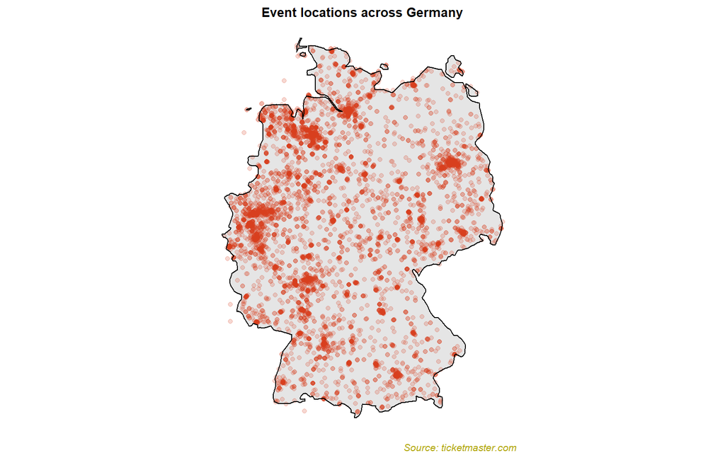

```r
venue_total_DE$longitude[venue_total_DE$longitude < 5.866944 | venue_total_DE$longitude > 15.043611] <- NA
venue_total_DE$latitude[venue_total_DE$latitude < 47.271679 | venue_total_DE$latitude > 55.0846] <- NA

plot_ex5_DE <- ggplot() +
  geom_polygon(aes(x = long, y = lat, group = group),
               data = map_data("world", region = "Germany"),
               fill = "grey90", color = "black") +
  theme_void() +
  coord_quickmap() +
  labs(title = "Event locations across Germany", caption = "Source: ticketmaster.com") +
  theme(plot.title = element_text(hjust = 0.5, size = 10, face = "bold", colour = "black"),
        plot.caption = element_text(size = 8, face = "italic", colour = "#B0A505")) +
  geom_point(aes(x = longitude, y = latitude), data = venue_total_DE,
             alpha = 0.2, col = "#D63D1C") +
  # added for border line to be at the front
  geom_polygon(aes(x = long, y = lat, group = group),
               data = map_data("world", region = "Germany"),
               fill = "transparent", color = "black")

plot_ex5_DE
```

## 6. Event locations in Sweden

I decided to apply the same operations to the country of Sweden.

```r
get_search_result_ex6 <- GET("https://app.ticketmaster.com/discovery/v2/venues.json",
                         query = list(apikey = api_key,
                                      countryCode = "SE",
                                      locale = "*"))

json_parsed_search_ex6 <- fromJSON(content(get_search_result_ex6, as = "text"))

venue_data_ex6 <- data.frame(
  name = json_parsed_search_ex6[["_embedded"]]$venues$name,
  city = json_parsed_search_ex6[["_embedded"]]$venues$city$name,
  postalCode = json_parsed_search_ex6[["_embedded"]]$venues$postalCode,
  address = json_parsed_search_ex6[["_embedded"]]$venues$address$line1,
  url = json_parsed_search_ex6[["_embedded"]]$venues$url,
  longitude = as.double(json_parsed_search_ex6[["_embedded"]]$venues$location$longitude),
  latitude = as.double(json_parsed_search_ex6[["_embedded"]]$venues$location$latitude)
  )

glimpse(venue_data_ex6)
```

```
## Rows: 20
## Columns: 7
## $ name       <chr> "Cirkus", "Garden, Konsert & Kongress", "Göta Lejon", "T...
## $ city       <chr> "Stockholm", "Linköping", "Stockholm", "Johanneshov", "S...
## $ postalCode <chr> NA, NA, "116 21", "12162", NA, "41138", NA, "302 44", NA...
## $ address    <chr> "Djurgårdsslätten 43-45", "Konsistoriegatan 7", "Götgata...
## $ url        <chr> "https://www.ticketmaster.se/venue/cirkus-stockholm-bilj...
## $ longitude  <dbl> 18.09969, 15.61516, 18.07384, 18.07929, 18.05621, 11.976...
## $ latitude   <dbl> 59.32457, 58.41323, 59.31378, 59.29285, 59.32982, 57.704...
```

In order to extract all event locations from the Scandinavian country, I only had to change the `country_code` parameter in the function from above reaping the benefits from my clean code.

```r
call_SE <- ticketmaster_call(api_key, "SE")

sum(call_SE$status_check != 200)
```

```
## [1] 1
```

```r
sum(call_SE$status_check_redo != 200)
```

```
## [1] 0
```

```r
venue_total_SE <- call_SE$data
glimpse(venue_total_SE)
```

```
## Rows: 7,834
## Columns: 7
## $ name       <chr> "Cirkus", "Garden, Konsert & Kongress", "Göta Lejon", "T...
## $ city       <chr> "Stockholm", "Linköping", "Stockholm", "Johanneshov", "S...
## $ postalCode <chr> NA, NA, "116 21", "12162", NA, "41138", NA, "302 44", NA...
## $ address    <chr> "Djurgårdsslätten 43-45", "Konsistoriegatan 7", "Götgata...
## $ url        <chr> "https://www.ticketmaster.se/venue/cirkus-stockholm-bilj...
## $ longitude  <dbl> 18.09969, 15.61516, 18.07384, 18.07929, 18.05621, 11.976...
## $ latitude   <dbl> 59.32457, 58.41323, 59.31378, 59.29285, 59.32982, 57.704...
```

I adjusted the colors to match the Swedish flag:

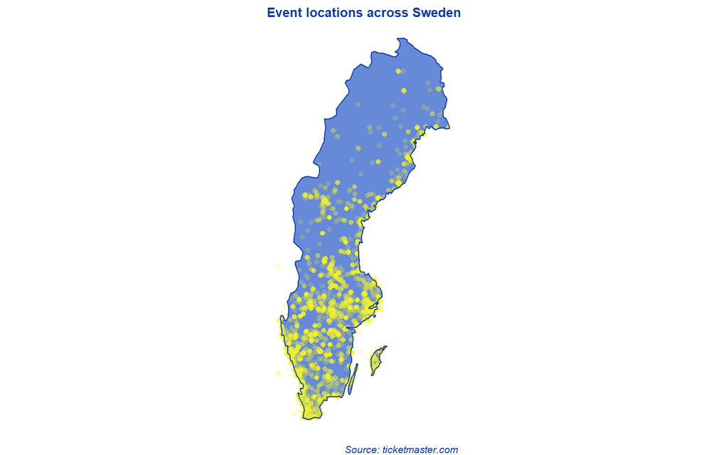

```r
venue_total_SE$longitude[venue_total_SE$longitude < 10.9575 | venue_total_SE$longitude > 24.155833] <- NA
venue_total_SE$latitude[venue_total_SE$latitude < 55.336944 | venue_total_SE$latitude > 69.06] <- NA

plot_ex6_SE <- ggplot() +
  geom_polygon(aes(x = long, y = lat, group = group),
               data = map_data("world", region = "Sweden"),
               fill = "#6689D8", color = "#0C39A7") +
  theme_void() +
  coord_quickmap() +
  labs(title = "Event locations across Sweden", caption = "Source: ticketmaster.com") +
  theme(plot.title = element_text(hjust = 0.5, size = 10, face = "bold", colour = "#0C39A7"),
        plot.caption = element_text(size = 8, face = "italic", colour = "#0C39A7")) +
  geom_point(aes(x = longitude, y = latitude), data = venue_total_SE,
             alpha = 0.2, col = "#F1F127") +
  # added for border line to be at the front
  geom_polygon(aes(x = long, y = lat, group = group),
               data = map_data("world", region = "Sweden"),
               fill = "transparent", color = "#0C39A7")

plot_ex6_SE
```